# 52414 - lab 1 Solutions

##10. Filtering the countries with at least 2000 difference(colored in blue in the first plot) and extracting 3 countries with +2000 difference from the plot

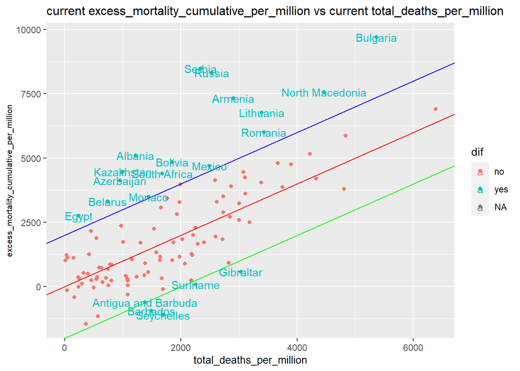

```r
# Solution code in R:

# a. current excess_mortality_cumulative_per_million vs current total_deaths_per_million plot with the lines: y=x in red, y= x+2000 in blue and y=x-2000 in green.

current %>% mutate(dif = ifelse((excess_mortality_cumulative_per_million>=total_deaths_per_million+2000)|(excess_mortality_cumulative_per_million<=total_deaths_per_million-2000),"yes","no")) %>%
  ggplot(aes(total_deaths_per_million,excess_mortality_cumulative_per_million,col=dif))+
  geom_point()+
  geom_abline(slope = 1,intercept = 1,col="red")+
  geom_abline(slope = 1,intercept = 2000,col="blue")+
  geom_abline(slope = 1,intercept = -2000,col="green")+
  geom_text(aes(label = ifelse(dif=="yes",location,"")))+
  labs(title = "current excess_mortality_cumulative_per_million vs current total_deaths_per_million")+
  theme(
  plot.title = element_text(size = 12),
  axis.title.x = element_text(size = 10),
  axis.title.y = element_text(size = 8))
```

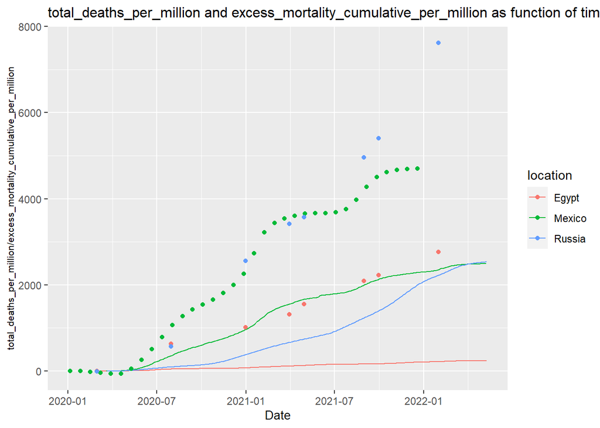

```r
# b. total_deaths_per_million(lines) and excess_mortality_cumulative_per_million(points) as function of time plot for Russia,Egypt and Mexico (three countries where the excess mortality was at least 2000 per million *above* the covid death rate)
cases %>% filter(location==c("Russia","Egypt","Mexico")) %>% ggplot()+
  geom_line(aes(date,total_deaths_per_million,col=location))+
  geom_point(aes(date,excess_mortality_cumulative_per_million,col=location))+
  labs(title = "total_deaths_per_million and excess_mortality_cumulative_per_million as function of time",
       x = "Date",
       y ="total_deaths_per_million/excess_mortality_cumulative_per_million")+
  theme(
  plot.title = element_text(size = 12),
  axis.title.x = element_text(size = 10),
  axis.title.y = element_text(size = 8))
```

In the first plot the countries above the blue line and beneath the green line have at least 2000 difference in the explained deaths by covid. the second plot shows that for all 3 countries the biggest difference is from mid 2021 until today, probably because the boosters and the vaccinations reduced covid death(the began then).